# Data Series Forecasting

### Objective:

To forecast **directionality** and **volatility** of three variables by

1. Analyzing each variable **independently** (univariate approach)
2. Incorporating relationship **between variables** (multivariate approach)

### 1. Univaraite forecasting

Each variable is used to generate its own predictions. For this analysis, non-parametric models are trained from a partition of the variable and validated on a following partition of the same variable, instead of predicting directionality or volatility directly. For a given algorithm, the best combination of parameters are selected based on aggregated prediction accuracy from multiple partitions. The algorithms are:

- [Auto-regessive Moving Average(ARMA)](https://en.wikipedia.org/wiki/Autoregressive%E2%80%93moving-average_model)
- [Gaussian Process Regression](https://en.wikipedia.org/wiki/Gaussian_process)

#### 1.1 Import libraries and define functions

```python
import os
import pandas as pd
import numpy as np
from matplotlib import pyplot as plt
from statsmodels.tsa.arima_model import ARMA
from sklearn.gaussian_process import GaussianProcessRegressor
from sklearn.gaussian_process.kernels \
    import RBF, WhiteKernel, RationalQuadratic, ExpSineSquared

def calc_score(y_true, y_pred):
    residuals = [y_true[k]-y_pred[k] for k in range(len(y_true))]
    squared_residuals = [resi**2 for resi in residuals]
    sum_squared_residuals = reduce(lambda x,y: x+y, squared_residuals)

    y_mean = sum(y_true)/float(len(y_true))
    squares = [(data-y_mean)**2 for data in y_true]
    sum_squares = reduce(lambda x,y: x+y, squares)
    r2 = 1-sum_squared_residuals/sum_squares
    return r2

def moving_window_arma(df, varname, indexes, p, q):
    train_num = 60
    val_num = 10
    rmse_list = []
    for index in indexes:
        y_train = df[varname].values[index:index+train_num]
        y_val = df[varname].values[index+train_num:index+train_num+val_num]
        try:
            model_arma = ARMA(y_train, order = (p, q)).fit()
            y_hat = model_arma.predict(train_num, train_num+val_num)
            y_hat = y_hat[1:]
            rmse = calc_score(y_val, y_hat)
            rmse_list.append(rmse)
        except:
            pass
    return rmse_list

def best_arma(df, varname, indexes):
    bestModel = []
    bestScore = -1e10

    pq = [(4, 2), (7, 4), (10, 5)]

    for (p,q) in pq:
        rmse_list = moving_window_arma(df, varname, indexes, p, q)
        score = np.nanmean(rmse_list)
        if score > bestScore:
            bestModel = (p, q)
            bestScore = score

    return bestModel, bestScore

def moving_window_gpr(df, varname, indexes, gp):
    train_num = 60
    val_num = 10
    X_train = np.arange(0, train_num).reshape(-1,1)
    rmse_list = []
    for index in indexes:
        y_train = df[varname].values[index:index+train_num]
        y_val = df[varname].values[index+train_num:index+train_num+val_num]
        try:
            model_gpr = gp.fit(X_train, y_train)
            y_hat = model_gpr.predict(np.linspace(X_train.max()+1, X_train.max() + val_num, val_num)[:, np.newaxis])
            rmse = calc_score(y_val, y_hat)
            rmse_list.append(rmse)
        except:
            pass
    return rmse_list

def best_gpr(df, varname, indexes):
    bestModel = None
    bestScore = -1e10

    kernel_irreg = 0.5**2 * RationalQuadratic(length_scale=10, alpha=1)
    kernel_noise = 0.1**2 * RBF(length_scale=0.1) \
                    + WhiteKernel(noise_level=0.1**2,
                                  noise_level_bounds=(1e-3, np.inf))

    periodicities = [5, 10, 20]
    length_scales = [100, 200, 300]
    for periodicity in periodicities:
        for length_scale in length_scales:
            kernel_longterm = 50**2 * RBF(length_scale=length_scale)
            kernel_season = 3**2 * RBF(length_scale=length_scale) \
                            * ExpSineSquared(length_scale=1, periodicity=10,
                                             periodicity_bounds="fixed")
            kernel = kernel_longterm + kernel_season + kernel_irreg + kernel_noise
            gp = GaussianProcessRegressor(kernel=kernel, alpha=0,
                              optimizer=None, normalize_y=True)
            rmse_list = moving_window_gpr(df, varname, indexes, gp)
            score = np.nanmean(rmse_list)
            if score > bestScore:
                bestModel = gp
                bestScore = score

    return bestModel, bestScore
```

#### 1.2 Import data from Excel and define variable names

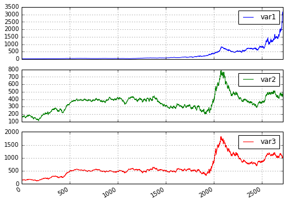

```python
os.chdir('F:\Code')
varnames = ['var1', 'var2', 'var3']
df = pd.read_excel('wenyu_data.xlsx', header=None, names = varnames)
%pylab inline
init_plot = df.plot(figsize=(8,6), subplots=True, grid=True)
```

#### 1.3 Define parameters

`train_num` is the length of training window, and `val_num` is the validation window.

```python
#In this case, 60 data points will be used for training
#and the next 10 data points will be used for validation
train_num = 60
val_num = 10
```

#### 1.4 Model training, selection and testing for data series prediction

Best models from both algorithms are generated, then the best model is selected based on the scores and eventually tested on the last 60 data points to generate prediction. Volatility and directionality are then calculated.

```python
results = pd.DataFrame(columns = ['Variable', 'Model', 'Score', 'Directionality', 'Volatility'])
results['Variable'] = varnames

for varname in varnames:
    indexes = np.random.choice(range(len(df)-(train_num+val_num)), 100, replace=False)
    model_arma, score_arma = best_arma(df, varname, indexes)
    model_gpr, score_gpr = best_gpr(df, varname, indexes)

    best_score, best_model_str, best_model = max(zip([score_arma, score_gpr],
                                                     ['arma', 'gpr'],
                                                     [model_arma, model_gpr]))

    X_test = np.arange(0, train_num).reshape(-1,1)
    y_test = df.loc[len(df)-train_num:, varname].values

    if best_model_str is 'arma':
        p_arma = model_arma[0]; q_arma = model_arma[1];
        try:
            model = ARMA(y_test, order = (p_arma, q_arma)).fit()
            model_arma.predict(train_num, train_num+val_num)
        except:
            best_model_str = 'gpr'
            best_score = score_gpr
            model = model_gpr.fit(X_test, y_test)
            y_pred = model_gpr.predict(np.linspace(X_test.max()+1, X_test.max() + val_num, val_num)[:, np.newaxis])
    else:
        model = model_gpr.fit(X_test, y_test)
        y_pred = model_gpr.predict(np.linspace(X_test.max()+1, X_test.max() + val_num, val_num)[:, np.newaxis])

    directionality = 1 if y_pred[-1]-y_pred[0]>0 else 0
    volatility = np.std(y_pred)

    result_index = results['Variable']==varname
    results.loc[result_index, 'Model'] = best_model_str
    results.loc[result_index, 'Score'] = best_score
    results.loc[result_index, 'Directionality'] = directionality
    results.loc[result_index, 'Volatility'] = volatility
```

```python
print results
```

```
  Variable Model    Score Directionality Volatility
0     var1   gpr -6.26909              1    128.012
1     var2   gpr -5.47458              1    16.4007
2     var3   gpr -6.22554              1    23.3391
```

### 2. Multivariate forecasting

For each observation in the data, various features are extracted and multiple prediction horizons are defined. Three algorithms are used to train models on randomly selected observations, while the other observations are used as unseen data to evaluate accuracy. Best model for each algorithm is selected based on parameter grid search, and best algorithm is selected to generate prediction results.

#### 2.1 Import libraries and define functions

A few functions are defined to:

1. calculate directionality and volatility in the future as prediction targets, where prediction horizon is a parameter for user to define
2. calculate directionality, volatility and other statistical features from a window of past data, where window size is also a parameter
3. grid search functions to select the best models for each of three algorithms used. Directionality is treated as a binary classification problem, and volatility is a regression problem. The algorithms are:
   - [Genetic Programming](https://en.wikipedia.org/wiki/Genetic_programming)
   - [Neural Networks](https://en.wikipedia.org/wiki/Artificial_neural_network)
   - [Random Forest](https://en.wikipedia.org/wiki/Random_forest)

```python
import os
import pandas as pd
import numpy as np
from matplotlib import pyplot as plt
from gplearn.genetic import SymbolicRegressor
from sklearn.neural_network import MLPRegressor
from sklearn.ensemble import RandomForestRegressor
from sklearn.neural_network import MLPClassifier
from sklearn.ensemble import RandomForestClassifier
from sklearn.metrics import zero_one_loss

def is_up_in_days(df, varname, no):
    var_diff = df[varname].diff(periods=no)[no:]
    is_up_in_days = np.array([True if np.sign(num)==1 else False for num in var_diff]).reshape(len(df)-no,1)
    is_up_in_days = np.vstack((is_up_in_days, np.nan*np.ones((no,1))))
    return is_up_in_days

def vol_in_days(df, varname, no):
    var_rolling_std = df[varname].rolling(window=no,center=False).std(ddof=0).values[no:].reshape(len(df)-no,1)
    vol_in_days = np.vstack((var_rolling_std, np.nan*np.ones((no,1))))
    return vol_in_days

def is_up_past_days(df, varname, no):
    var_diff = df[varname].diff(periods=no)[no:]
    is_up_in_days = np.array([True if np.sign(num)==1 else False for num in var_diff]).reshape(len(df)-no,1)
    is_up_past_days = np.vstack((np.nan*np.ones((no,1)), is_up_in_days))
    return is_up_past_days

def vol_past_days(df, varname, no):
    vol_past_days = df[varname].rolling(window=no,center=False).std(ddof=0).values
    return vol_past_days

def feat_past_days(df, varname, no, feat):
    var_rolling_window = df[varname].rolling(window=no, center=False)
    var_rolling_feat = getattr(var_rolling_window, feat)()
    return var_rolling_feat

def best_gp(X_train, y_train, X_val, y_val, classifier=True):
    bestModel = None
    bestScore = 0 if classifier else -1e10

    popSizes = [1000, 2000, 5000]
    highParams = range(4)

    for popSize in popSizes:
        for highParam in highParams:
            params = [0.1]*4
            params[highParam] = 0.7
            model_gp = SymbolicRegressor(population_size=popSize,
                                         generations=25, stopping_criteria=0.01,
                                         p_crossover=params[0], p_subtree_mutation=params[1],
                                         p_hoist_mutation=params[2], p_point_mutation=params[3],
                                         max_samples=0.9, verbose=0,
                                         parsimony_coefficient=0.01, random_state=42)
            model_gp.fit(X_train, y_train.values.ravel())
            if classifier:
                y_hat = model_gp.predict(X_val)
                y_hat = np.round(y_hat)
                score = 1 - zero_one_loss(y_val, y_hat)

            else:
                score = model_gp.score(X_val, y_val)

            if (score > bestScore):
                bestModel = model_gp
                bestScore = score

    return bestModel, bestScore

def best_nn(X_train, y_train, X_val, y_val, classifier=True):
    bestModel = None
    bestScore = 0 if classifier else -1e10

    layerSizes = [50, 100, 200]
    Solvers= ['adam', 'sgd']

    for layerSize in layerSizes:
        for solver in Solvers:
            if classifier:
                model_nn = MLPClassifier(hidden_layer_sizes=layerSize, solver=solver)
            else:
                model_nn = MLPRegressor(hidden_layer_sizes=layerSize, solver=solver)

            model_nn.fit(X_train, y_train.values.ravel())
            if classifier:
                y_hat = model_nn.predict(X_val)
                score = 1 - zero_one_loss(y_val, y_hat)

            else:
                score = model_nn.score(X_val, y_val)

            if (score > bestScore):
                bestModel = model_nn
                bestScore = score

    return bestModel, bestScore

def best_rf(X_train, y_train, X_val, y_val, classifier=True):
    bestModel = None
    bestScore = 0 if classifier else -1e10

    numEsts = [50, 100, 200]
    maxDepths = [3, 6, 9]

    for numEst in numEsts:
        for maxDepth in maxDepths:
            if classifier:
                model_rf = RandomForestClassifier(n_estimators=numEst, max_depth=maxDepth)
            else:
                model_rf = RandomForestRegressor(n_estimators=numEst, max_depth=maxDepth)

            model_rf.fit(X_train, y_train.values.ravel())
            if classifier:
                y_hat = model_rf.predict(X_val)
                score = 1 - zero_one_loss(y_val, y_hat)

            else:
                score = model_rf.score(X_val, y_val)

            if (score > bestScore):
                bestModel = model_rf
                bestScore = score

    return bestModel, bestScore
```

#### 2.2 Import data from Excel and define variable names

```python
os.chdir('F:\Code')
varnames = ['var1', 'var2', 'var3']
df = pd.read_excel('wenyu_data.xlsx', header=None, names = varnames)
```

#### 2.3 Define analysis parameters, extract features and prediction targets

Parameters defined: time domain features, a series of window length for feature extraction, and a series of window length as prediction horizon. At the end, examples of features and targets are printed.

```python
features = ['mean', 'median', 'var', 'min', 'max', 'cov', 'skew', 'kurt']
past_window = [5, 10, 15, 22, 44, 66, 132]

feature_set = []
for varname in varnames:
    for window in past_window:
        for feat in features:
            feat_name = '_'.join((varname, str(window), feat))
            df[feat_name] = feat_past_days(df, varname, window, feat)
            feature_set.append(feat_name)
        feat_name = '_'.join((varname, str(window), 'vol')); feature_set.append(feat_name)
        df[feat_name] = vol_past_days(df, varname, window)
        feat_name = '_'.join((varname, str(window), 'is_up_past')); feature_set.append(feat_name)
        df[feat_name] = is_up_past_days(df, varname, window)


pred_window = [1, 3, 5, 22, 66]
pred_set_direction = []
pred_set_vol = []
for varname in varnames:
    for window in pred_window:
        feat_name = '_'.join((varname, 'is_up_in', str(window))); pred_set_direction.append(feat_name)
        df[feat_name] = is_up_in_days(df, varname, window)
        feat_name = '_'.join((varname, 'vol_in', str(window))); pred_set_vol.append(feat_name)
        df[feat_name] = vol_in_days(df, varname, window)

df.head(10)
```

|  | var1 | var2 | var3 | var1_5_mean | var1_5_median | var1_5_var | var1_5_min | var1_5_max | var1_5_cov | var1_5_skew | ... | var3_is_up_in_1 | var3_vol_in_1 | var3_is_up_in_3 | var3_vol_in_3 | var3_is_up_in_5 | var3_vol_in_5 | var3_is_up_in_22 | var3_vol_in_22 | var3_is_up_in_66 | var3_vol_in_66 |
| --- | --- | --- | --- | --- | --- | --- | --- | --- | --- | --- | --- | --- | --- | --- | --- | --- | --- | --- | --- | --- | --- |
| 0 | 14.45164 | 175.99 | 161.82 | NaN | NaN | NaN | NaN | NaN | NaN | NaN | ... | 0.0 | 0.0 | 0.0 | 4.508077 | 0.0 | 4.382719 | 0.0 | 4.390065 | 1.0 | 8.128291 |
| 1 | 14.71521 | 173.79 | 160.44 | NaN | NaN | NaN | NaN | NaN | NaN | NaN | ... | 0.0 | 0.0 | 0.0 | 3.259785 | 0.0 | 3.290109 | 0.0 | 4.326200 | 1.0 | 8.156370 |
| 2 | 14.92905 | 171.10 | 157.82 | NaN | NaN | NaN | NaN | NaN | NaN | NaN | ... | 0.0 | 0.0 | 0.0 | 2.160746 | 0.0 | 2.373003 | 1.0 | 4.617640 | 1.0 | 8.287269 |
| 3 | 15.16776 | 162.01 | 149.84 | NaN | NaN | NaN | NaN | NaN | NaN | NaN | ... | 1.0 | 0.0 | 1.0 | 2.658851 | 0.0 | 2.866531 | 1.0 | 4.854551 | 1.0 | 8.640669 |
| 4 | 15.19263 | 166.79 | 154.07 | 14.891258 | 14.92905 | 0.098241 | 14.45164 | 15.19263 | 0.098241 | -0.566339 | ... | 0.0 | 0.0 | 0.0 | 2.524735 | 0.0 | 3.058889 | 1.0 | 4.990782 | 1.0 | 8.883833 |
| 5 | 14.98376 | 162.17 | 149.20 | 14.997682 | 14.98376 | 0.037906 | 14.71521 | 15.19263 | 0.037906 | -0.594823 | ... | 1.0 | 0.0 | 0.0 | 3.120495 | 0.0 | 3.458703 | 1.0 | 5.298798 | 1.0 | 9.149022 |
| 6 | 15.22247 | 167.77 | 155.38 | 15.099134 | 15.16776 | 0.017726 | 14.92905 | 15.22247 | 0.017726 | -0.607252 | ... | 0.0 | 0.0 | 0.0 | 2.207548 | 0.0 | 2.039349 | 1.0 | 5.486853 | 1.0 | 9.444712 |
| 7 | 15.57556 | 164.87 | 152.09 | 15.228436 | 15.19263 | 0.046340 | 14.98376 | 15.57556 | 0.046340 | 1.123973 | ... | 0.0 | 0.0 | 0.0 | 0.589086 | 0.0 | 1.008968 | 1.0 | 6.033511 | 1.0 | 9.581053 |
| 8 | 15.46118 | 162.09 | 147.76 | 15.287120 | 15.22247 | 0.054657 | 14.98376 | 15.57556 | 0.054657 | 0.007818 | ... | 0.0 | 0.0 | 1.0 | 1.277532 | 1.0 | 2.183084 | 1.0 | 6.224478 | 1.0 | 9.555055 |
| 9 | 14.94398 | 161.01 | 147.12 | 15.237390 | 15.22247 | 0.078770 | 14.94398 | 15.57556 | 0.078770 | 0.156473 | ... | 0.0 | 0.0 | 1.0 | 1.239462 | 1.0 | 3.830762 | 1.0 | 6.013615 | 1.0 | 9.609063 |

10 rows × 243 columns

#### 2.4 Model training, selection and testing for directionality prediction

- Output: variable and prediction horizon as a target variable
- Model: the best model/algorithm for the output based on validation performance
- Score: a score for the model that is between 0 and 1, the higher the score is, the more confidence there is in the model
- Result: prediction outcome, 1 meaning **up** and 0 meaning **down**

```python
results_direction = pd.DataFrame(columns = ['Output', 'Model', 'Score', 'Result', 'Prob'])
results_direction['Output'] = pred_set_direction

for pred_var in pred_set_direction:
    df_new = df.loc[:, feature_set + [pred_var]]
    df_new.dropna(inplace=True); df_new.reset_index(drop=True, inplace=True)
    X = df_new.loc[:, feature_set]
    y = df_new.loc[:, pred_var]

    train_ind = np.random.rand(len(df_new)) < 0.67
    X_train = df_new.loc[train_ind, feature_set]
    y_train = df_new.loc[train_ind, pred_var]

    X_val = df_new.loc[~train_ind, feature_set]
    y_val = df_new.loc[~train_ind, pred_var]

    model_gp, score_gp = best_gp(X_train, y_train, X_val, y_val)
    model_rf, score_rf = best_rf(X_train, y_train, X_val, y_val)
    model_nn, score_nn = best_nn(X_train, y_train, X_val, y_val)

    best_score, best_model_str, best_model = max(zip([score_gp, score_nn, score_rf],
                                                     ['gp', 'nn', 'rf'],
                                                     [model_gp, model_nn, model_rf]))

    X_test = df.loc[len(df)-1, feature_set].values.reshape(1, -1)
    y_test = best_model.predict(X_test)

    if best_model_str != 'gp':
        probability = best_model.predict_proba(X_test)[0][y_test[0]]
    else:
        probability = np.nan

    result_index = results_direction['Output']==pred_var
    results_direction.loc[result_index, 'Model'] = best_model_str
    results_direction.loc[result_index, 'Score'] = best_score
    results_direction.loc[result_index, 'Result'] = y_test
    results_direction.loc[result_index, 'Prob'] = probability

print results_direction
```

```
              Output Model     Score Result      Prob
0    var1_is_up_in_1    nn   0.53341      1         1
1    var1_is_up_in_3    rf  0.682266      1  0.641073
2    var1_is_up_in_5    rf  0.738609      1  0.723509
3   var1_is_up_in_22    rf  0.889964      1  0.751779
4   var1_is_up_in_66    rf  0.931193      1  0.686847
5    var2_is_up_in_1    nn  0.534857      1         1
6    var2_is_up_in_3    rf  0.693141      1  0.569751
7    var2_is_up_in_5    rf  0.758007      1   0.65086
8   var2_is_up_in_22    rf  0.909091      0  0.723136
9   var2_is_up_in_66    rf  0.949133      1  0.625492
10   var3_is_up_in_1    rf  0.567599      1   0.50234
11   var3_is_up_in_3    rf  0.698357      1  0.556094
12   var3_is_up_in_5    rf  0.782249      1  0.556611
13  var3_is_up_in_22    rf  0.926437      0  0.568035
14  var3_is_up_in_66    rf   0.95572      0  0.603885
```

Genetic Programming can provide an explicit equation for the prediction, giving interpretability for users. The numbers after the `X` are the number of the feature, which is zero indexed. For example, `X1` is the 2nd feature

```python
print model_gp._program
```

```
min(X49, X69)
```

Random Forest can provide *feature importance*, which can be used to rank features and remove features of lowest importance scores

```python
feature_importance = model_rf.feature_importances_
feature_importance_relative = feature_importance/max(feature_importance)
feature_rank = zip(feature_importance_relative, feature_set); feature_rank.sort(reverse=True)
print "Top 3 features and their importances are: {0}".format(feature_rank[:3])
```

```
Top 3 features and their importances are: [(1.0, 'var3_22_max'), (0.76333818899145722, 'var3_15_median'), (0.75464199027715584, 'var3_10_max')]
```

#### 2.5 Model training, selection and testing for volatility prediction

A similar process for volatility prediction. Predictions for different variables and different horizons are computed.

- Output: variable and prediction horizon as a target variable
- Model: the best model/algorithm for the output based on validation performance
- Score: a score for the model that is the **R squared score** with max at 1, the higher the score is, the more confidence there is in the model
- Result: prediction outcome of volatility, which is standard deviation of data points in a window

```python
results_vol = pd.DataFrame(columns = ['Output', 'Model', 'Score', 'Result'])
results_vol['Output'] = pred_set_vol

for pred_var in pred_set_vol:
    df_new = df.loc[:, feature_set + [pred_var]]
    df_new.dropna(inplace=True); df_new.reset_index(drop=True, inplace=True)
    X = df_new.loc[:, feature_set]
    y = df_new.loc[:, pred_var]

    train_ind = np.random.rand(len(df_new)) < 0.67
    X_train = df_new.loc[train_ind, feature_set]
    y_train = df_new.loc[train_ind, pred_var]

    X_val = df_new.loc[~train_ind, feature_set]
    y_val = df_new.loc[~train_ind, pred_var]

    model_gp, score_gp = best_gp(X_train, y_train, X_val, y_val, classifier=False)
    model_rf, score_rf = best_rf(X_train, y_train, X_val, y_val, classifier=False)
    try:
        model_nn, score_nn = best_nn(X_train, y_train, X_val, y_val, classifier=False)
    except:
        model_nn = None
        score_nn = 0

    best_score, best_model_str, best_model = max(zip([score_gp, score_nn, score_rf],
                                                     ['gp', 'nn', 'rf'],
                                                     [model_gp, model_nn, model_rf]))

    X_test = df.loc[len(df)-1, feature_set].values.reshape(1, -1)
    y_test = best_model.predict(X_test)

    result_index = results_vol['Output']==pred_var
    results_vol.loc[result_index, 'Model'] = best_model_str
    results_vol.loc[result_index, 'Score'] = best_score
    results_vol.loc[result_index, 'Result'] = y_test

print results_vol
```

```
            Output Model     Score   Result
0    var1_vol_in_1    rf         1        0
1    var1_vol_in_3    rf  0.738307  105.145
2    var1_vol_in_5    rf  0.791959  135.772
3   var1_vol_in_22    rf  0.987545  356.132
4   var1_vol_in_66    rf  0.995789  317.943
5    var2_vol_in_1    rf         1        0
6    var2_vol_in_3    rf  0.452368   7.0495
7    var2_vol_in_5    rf   0.62049  9.31416
8   var2_vol_in_22    rf  0.915412  11.9737
9   var2_vol_in_66    rf  0.988633  15.0315
10   var3_vol_in_1    rf         1        0
11   var3_vol_in_3    rf  0.416998  16.1775
12   var3_vol_in_5    rf   0.74565  15.8766
13  var3_vol_in_22    rf  0.964546  38.1091
14  var3_vol_in_66    rf   0.99378  43.1968
```

### 3. Conclusion

Directionality prediction results are visualized in the bar chart below.

- The color of the bar represents the predicted outcome, where **green** is **Up** and **red** is **Down**.
- The length of a bar represents the probability of the prediction
- Scores of the models for each target are shown in black dotted line

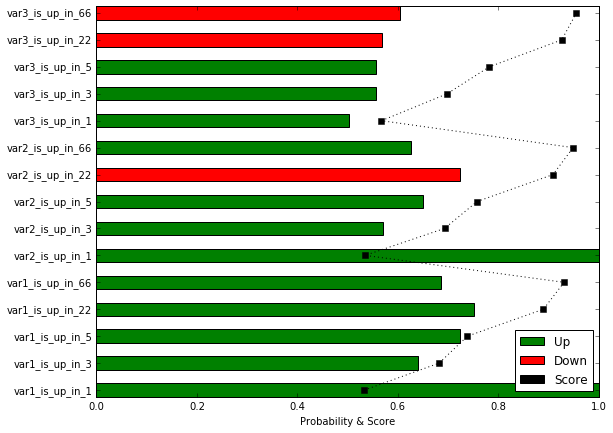

```python
import matplotlib.patches as mpatches
results_direction['ResultColor'] = ['g' if is_up else 'r' for is_up in results_direction['Result']]
fig, ax1 = plt.subplots(figsize=(9, 7))
pos = np.arange(len(results_direction)) + 0.5
barplot = ax1.barh(pos, results_direction['Prob'],
                   align='center',
                   height=0.5, color=results_direction['ResultColor'],
                   tick_label=results_direction['Output']
                   )
ax1.plot(results_direction['Score'], pos, 'ks:', label='Score')
ax1.set_xlabel('Probability & Score')
legend_class = ['Up', 'Down', 'Score']; legend_colors = ['g', 'r', 'k']
recs = [mpatches.Rectangle((0,0),1,1,fc=legend_colors[i]) for i in range(len(legend_class))]
ax1.legend(recs,legend_class,loc='best')
```

Volatility prediction results are visualized in the bar chart below.

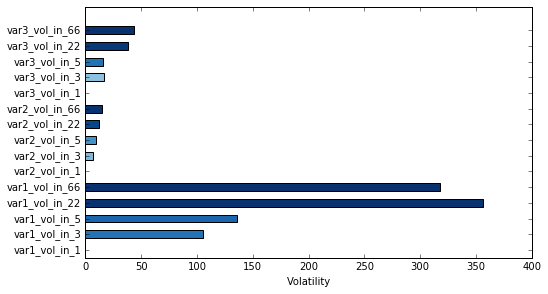

```python
Blues = plt.get_cmap('Blues')

fig, ax1 = plt.subplots(figsize=(8, 4.5))
pos = np.arange(len(results_vol)) + 0.5
norm = plt.Normalize()
colors = plt.cm.jet(norm(results_vol['Score'].values))
colors = [Blues(k) for k in results_vol['Score'].values]
cax = ax1.barh(pos, results_vol['Result'],
               align='center',
               height=0.5, color=colors,
               tick_label=results_vol['Output'])
ax1.set_xlabel('Volatility')
```